# L04 Maps

Data Visualization (STAT 302)

Author

Bud Green

## Overview

The goal of this lab is to explore various ways of building maps with `ggplot2`.

Challenges are not mandatory for students to complete. We highly recommend students attempt them though. *We would expect graduate students to attempt the challenges.*

## Datasets

We’ll be using the `US_income.rda` dataset which should be placed in the `/data` subdirectory in our **data_vis_labs** project. You’ll also be downloading your own data to build maps.

## Exercise 1

### Plot 1

Make a county map of a US state using `geom_polygon()`. Maybe use your home state or a favorite state. Please do NOT use the state in the ggplot2 book example.

Optional: Consider adding major cities (or your home town).

*Hints:*

- See section [6.1](https://ggplot2-book.org/maps.html#polygonmaps) in our book.
- Void theme

**Solution**

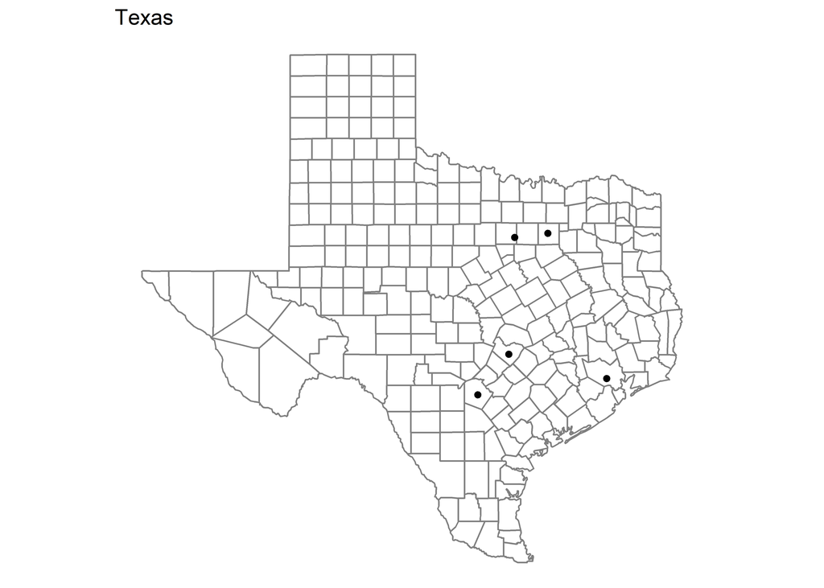

```r
#tx county data
tx_counties <- map_data("county", "texas") %>%
  select(lon = long, lat, group, id = subregion) %>%
  as_tibble()

tx_cities <- tibble(
  city_name = c("aledo", "dallas", "san antonio", "austin", "houston"),
  lat = c(32.690663904, 32.7767, 29.4241, 30.2672, 29.7604),
  lon = c(-97.601997592, -96.7970, -98.4936, -97.7431, -95.3698)
)

ggplot(data = tx_counties, aes(lon, lat)) +
  geom_polygon(
    aes(group = group),
    fill = "white",
    color = "grey50"
  ) +
  geom_point(data = tx_cities) +
  coord_quickmap() +
  theme_void() +
  ggtitle("Texas")
```

### Plot 2

Now use `geom_sf()` instead. You’ll need to download data for this. You can use either the `tigris` ([github page](https://github.com/walkerke/tigris)) or `geodata` packages. Either `tigris`’ `counties()` with `cb = TRUE` or `geodata`’s `gadm()` could be useful.

**Solution**

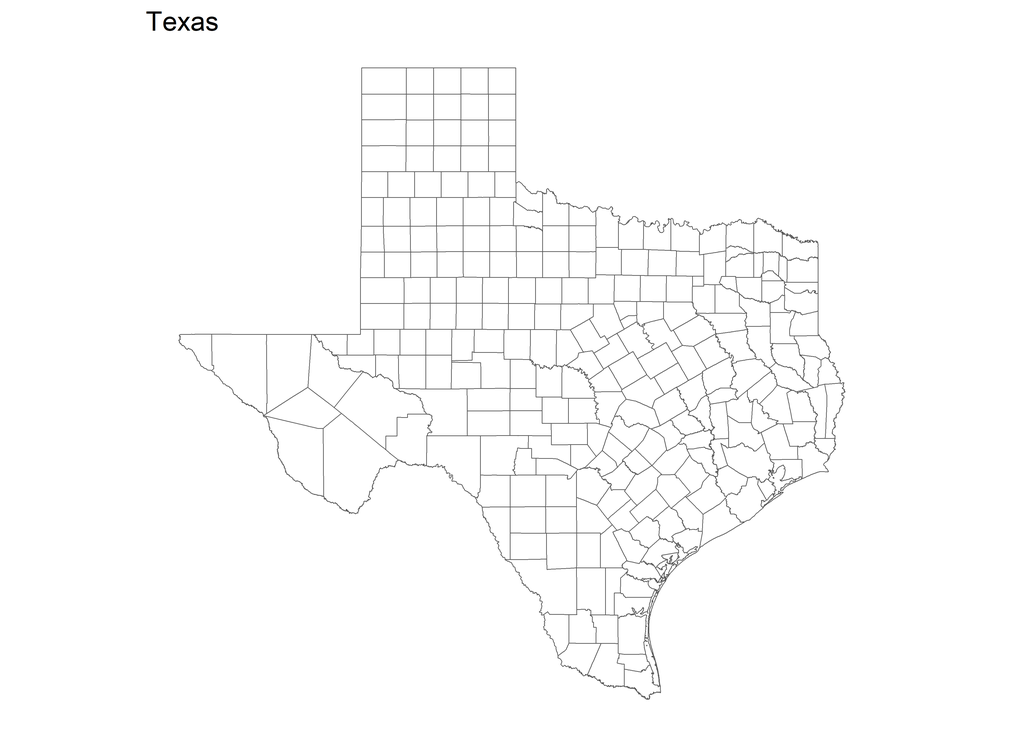

```r
tx_counties <- tigris::counties(state = "TX", cb = TRUE, progress_bar = FALSE)

ggplot(tx_counties) +
  geom_sf(fill = NA) +
  theme_void() +
  labs(title = "Texas")
```

## Exercise 2

Using the `US_income` dataset, recreate the following graphics as precisely as possible.

```r
# Setting income levels
US_income <- mutate(
  US_income,
  income_bins = cut(
    ifelse(is.na(median_income), 25000, median_income),
    breaks = c(0, 40000, 50000, 60000, 70000, 80000),
    labels = c("< $40k", "$40k to $50k",
               "$50k to $60k", "$60k to $70k", "> $70k"),
    right = FALSE
  )
)
```

*Hints:*

- `geom_sf()` — boundary color is `"grey80"` and size is 0.2
- `viridis` package (`discrete = TRUE` in `scale_*` function)
- Void theme

**Solution**

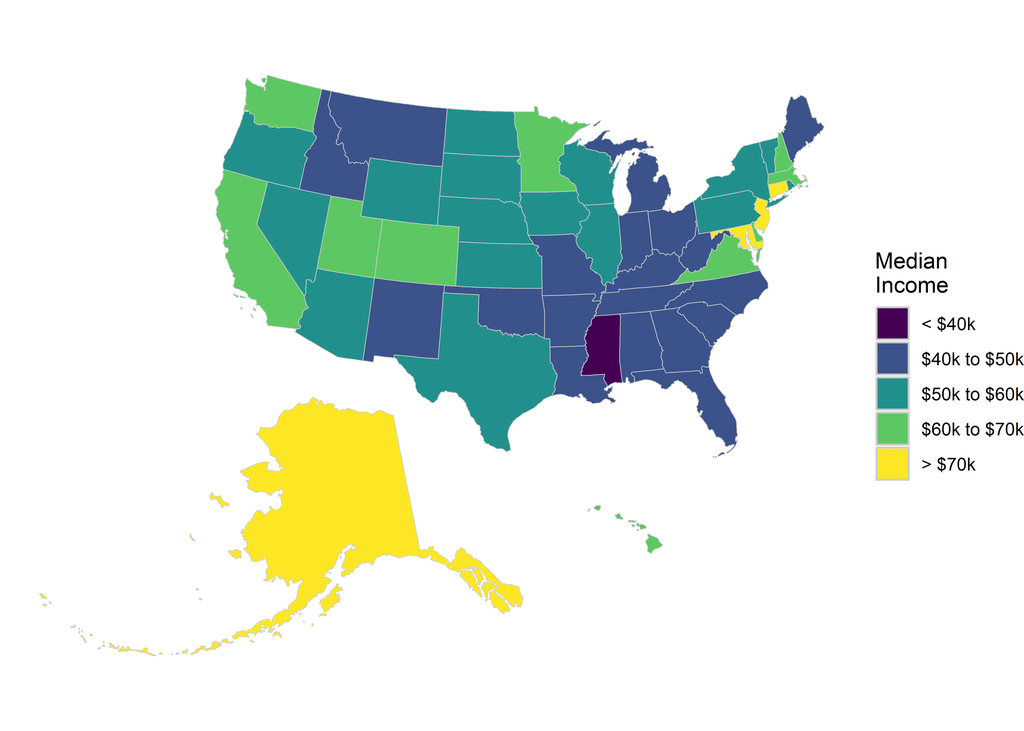

```r
ggplot(data = US_income) +
  geom_sf(aes(fill = income_bins), color = "grey80", size = 0.2) +
  scale_fill_viridis_d() +
  theme_void() +
  labs(fill = paste("Median", "\nIncome"))
```

### Plot 2

*Hints:*

- `statebins::geom_statebins()`
- `viridis` package (`discrete = TRUE` in `scale_*` function)
- Statebins theme

**Solution**

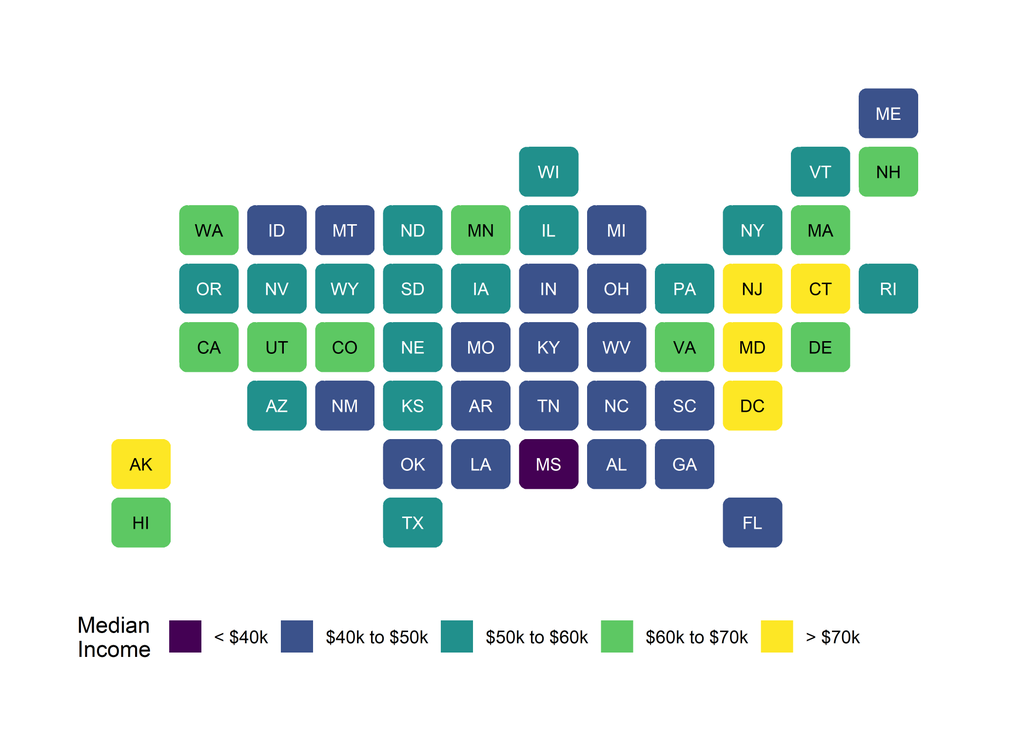

```r
ggplot(data = US_income) +
  geom_statebins(aes(state = name, fill = income_bins)) +
  scale_fill_viridis_d() +
  theme_statebins() +
  labs(fill = paste("Median", "\nIncome"))
```

## Exercise 3

Pick any city or foreign country to build a map for. You can dress it up or make it as basic as you want. Also welcome to try building a graphic like that depicted at the end of section [6.5](https://ggplot2-book.org/maps.html#rastermaps) — use a different region though.

**Solution**

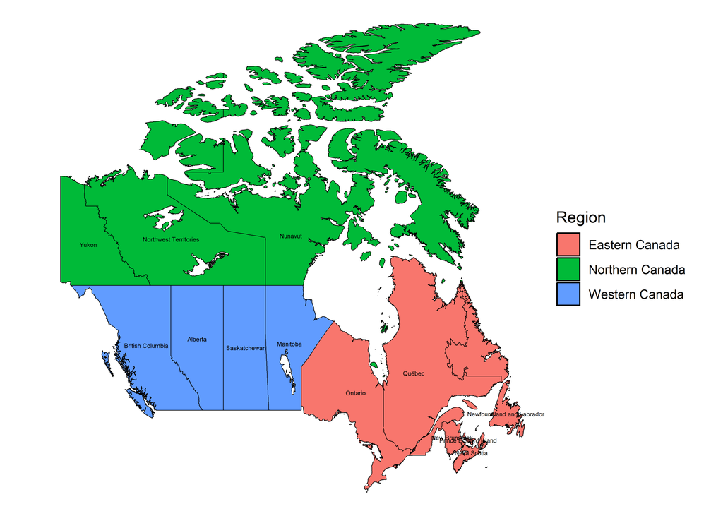

```r
canada_provinces <- ne_states(country = "canada", returnclass = "sf")

ggplot() +
  geom_sf(data = canada_provinces, aes(fill = region), color = "black", size = 5) +
  geom_text(data = canada_provinces, aes(label = name, x = longitude, y = latitude), size = 1.5, color = "black") +
  theme_void() +
  labs(fill = "Region")
```

## Challenge(s)

**Optional**

**Solution**

This was not happening for me. I tried to do a lot of different things for this and the last one and just none of them worked the way I wanted them to.